# Lecture 4.1: Data Analysis Tools Part 2

SIPA U6614 | Instructor: Harold Stolper

# 1 Introduction

Load packages:

```r
library(tidyverse)
library(gapminder)
```

Resources used to create this lesson:

- https://dplyr.tidyverse.org/reference/join.html
- https://stat545.com/join-cheatsheet.html
- https://mgimond.github.io/ES218/Week03c.html
- https://www.guru99.com/r-apply-sapply-tapply.html

# 2 Joins

In this section we’ll review functions in the `dplyr` package for joining columns of data from one data frame to another.

We’ll be using the gapminder dataset again, with country-year observations on average life expectancy, population, and GPD per capita. Remember to load the library and then take a minute to re-familiarize yourself with the dataset. Let’s filter out gapminder observations for all years besides 2002 and 2007, and for the time-being we’re also going to treat country as a character rather an a factor – joining on a factor can sometimes cause a bit of trouble down the road.

```r
#filter gapminder for 2002 and 2007 and coerce country from factor to char
gap <- gapminder %>%
  filter(year == 2007 | year == 2002) %>%
  mutate(country = as.character(country))

#inspect new data frame
str(gap)
```

```
## tibble [284 × 6] (S3: tbl_df/tbl/data.frame)
##  $ country  : chr [1:284] "Afghanistan" "Afghanistan" "Albania" "Albania" ...
##  $ continent: Factor w/ 5 levels "Africa","Americas",..: 3 3 4 4 1 1 1 1 2 2 ...
##  $ year     : int [1:284] 2002 2007 2002 2007 2002 2007 2002 2007 2002 2007 ...
##  $ lifeExp  : num [1:284] 42.1 43.8 75.7 76.4 71 ...
##  $ pop      : int [1:284] 25268405 31889923 3508512 3600523 31287142 33333216 10866106 12420476 38331121 40301927 ...
##  $ gdpPercap: num [1:284] 727 975 4604 5937 5288 ...
```

```r
head(gap, n = 5)
```

```
## # A tibble: 5 x 6
##   country     continent  year lifeExp      pop gdpPercap
##   <chr>       <fct>     <int>   <dbl>    <int>     <dbl>
## 1 Afghanistan Asia       2002    42.1 25268405      727.
## 2 Afghanistan Asia       2007    43.8 31889923      975.
## 3 Albania     Europe     2002    75.7  3508512     4604.
## 4 Albania     Europe     2007    76.4  3600523     5937.
## 5 Algeria     Africa     2002    71.0 31287142     5288.
```

Even though `country` is stored as a character, we can still temporarily treat it as a factor in order to count the number of distinct countries observed in the gapminder data for 2002 and 2007 without changing the data frame stored in memory.

```r
#check how many countries are in the gap data frame
str(as.factor(gap$country))
```

```
##  Factor w/ 142 levels "Afghanistan",..: 1 1 2 2 3 3 4 4 5 5 ...
```

```r
#better for in-line code references
n_distinct(gap$country)
```

```
## [1] 142
```

To learn different `dplyr` join functions, we’ll be working with a data frame including annual country-level observations from the [World Bank](https://data.worldbank.org/indicator/SH.XPD.CHEX.PC.CD) on health expenditures per capita (from 2002-2017). Let’s load the health expenditure data and take a look.

```r
#load and inspect healthexp data
healthexp <- readRDS("healthexp_long.rds")
str(healthexp, give.attr = FALSE)
```

```
## 'data.frame':    4224 obs. of  4 variables:
##  $ country       : chr  "Aruba" "Afghanistan" "Angola" "Albania" ...
##  $ Indicator.Name: chr  "Current health expenditure per capita (current US$)" "Current health expenditure per capita (current US$)" "Current health expenditure per capita (current US$)" "Current health expenditure per capita (current US$)" ...
##  $ year          : num  2002 2002 2002 2002 2002 ...
##  $ healthexp     : num  NA 16.2 29 NA 2256.3 ...
```

```r
head(healthexp, n = 5)
```

```
## # A tibble: 5 x 4
##   country     Indicator.Name                                      year healthexp
##   <chr>       <chr>                                              <dbl>     <dbl>
## 1 Aruba       Current health expenditure per capita (current US…  2002      NA
## 2 Afghanistan Current health expenditure per capita (current US…  2002      16.2
## 3 Angola      Current health expenditure per capita (current US…  2002      29.0
## 4 Albania     Current health expenditure per capita (current US…  2002      NA
## 5 Andorra     Current health expenditure per capita (current US…  2002    2256.
```

Note that the gapminder data includes observations for 142 countries 5 years apart, e.g. 2002 and 2007, while the health expenditure data includes annual observations for 264 countries between 2002 and 2017.

## 2.1 Mutating joins

In the parlance of `dplyr`, a *mutating join* refers to merging in new columns of data to existing columns of data. Let’s review the different types of mutating joins.

### 2.1.1 `inner_join`

`inner_join(df1, df2, by = col_to_join_by)` returns all rows in `df1` with values for `col_to_join_by` that match values in `df2`, and including all columns from both `df1` and `df2`. In this case we want to match on two columns that appear in both data frames, `country` and `year`. This means that the `col_to_join_by` argument should be specified as a vector of two columns, as you can see in the code chunk below.

Keep in mind that if there are multiple matches between `df1` and `df2`, all combinations of the matches are returned, which may not be what you want. This is considered a mutating join because we’re adding columns to an existing data frame, in a similar fashion as the `mutate` function.

```r
#inner join by country-year with gap on the left, healthexp on the right
gap_joined_inner <-
  inner_join(gap, healthexp, by = c("country", "year")) %>%
  mutate(country = as.factor(country))

#inspect results of inner join
gap_joined_inner %>% head(n = 5)
```

```
## # A tibble: 5 x 8
##   country  continent  year lifeExp    pop gdpPercap Indicator.Name     healthexp
##   <fct>    <fct>     <dbl>   <dbl>  <int>     <dbl> <chr>                  <dbl>
## 1 Afghani… Asia       2002    42.1 2.53e7      727. Current health ex…      16.2
## 2 Afghani… Asia       2007    43.8 3.19e7      975. Current health ex…      31.8
## 3 Albania  Europe     2002    75.7 3.51e6     4604. Current health ex…      NA
## 4 Albania  Europe     2007    76.4 3.60e6     5937. Current health ex…      NA
## 5 Algeria  Africa     2002    71.0 3.13e7     5288. Current health ex…      66.2
```

```r
str(gap_joined_inner)
```

```
## tibble [264 × 8] (S3: tbl_df/tbl/data.frame)
##  $ country       : Factor w/ 132 levels "Afghanistan",..: 1 1 2 2 3 3 4 4 5 5 ...
##  $ continent     : Factor w/ 5 levels "Africa","Americas",..: 3 3 4 4 1 1 1 1 2 2 ...
##  $ year          : num [1:264] 2002 2007 2002 2007 2002 ...
##  $ lifeExp       : num [1:264] 42.1 43.8 75.7 76.4 71 ...
##  $ pop           : int [1:264] 25268405 31889923 3508512 3600523 31287142 33333216 10866106 12420476 38331121 40301927 ...
##  $ gdpPercap     : num [1:264] 727 975 4604 5937 5288 ...
##  $ Indicator.Name: chr [1:264] "Current health expenditure per capita (current US$)" "Current health expenditure per capita (current US$)" "Current health expenditure per capita (current US$)" "Current health expenditure per capita (current US$)" ...
##  $ healthexp     : num [1:264] 16.2 31.8 NA NA 66.2 ...
```

Note that all columns from the “right-hand” data frame (`healthexp`) that aren’t already in the “left-hand” data frame (`gap`) are added as new columns at the end of the new, joined data frame: `Indicator.Name` and `healthexp`. The new joined data frame now has 8 columns in total.

A requirement for a successful join is that the merging variable(s), in this case combinations of `country` and `year`, are coded identically in both data frames. For `year` this is pretty straightforward, visual inspection confirms years are coded as a familiar four digit number. For `country`, on the other hand, different spellings for the same country name in both data frames will prevent a match. This means it’s critical to inspect the coding of `country` in each data frame and the results of the join to find any coding inconsistencies that need to be addressed.

Also note that if the columns you’re matching on have different names in each data frame, you can modify the `by` argument as `by = c("left_col" = "right_col")`.

In the previous code chunk, we *coerced* `country` in the joined data frame from a character back to a factor, and we can confirm that 132 factor levels for `country` (e.g. countries) from `gap` were retained in the inner join. This means 10 countries in the gapminder data were not matched to the health expenditure data.

```r
#use nlevels function to show how many factor levels for country survived the join
nlevels(gap_joined_inner$country)
```

```
## [1] 132
```

How can we identify the 10 countries that weren’t matched? There are a number of ways to do this, but let’s pause that discussion until we introduce filtering joins.

### 2.1.2 `full_join`

`full_join(df1, df2, by = col_to_join_by)` return all rows and all columns from both `df1` and `df2`. For rows in each one data frame with no matching values for `col_to_join_by` in the other, the rows are retained with `NA` values assigned to elements of missing column data. If there are multiple matches between `df1` and `df2`, all combination of the matches are returned, which once again may not be what you want. This is a mutating join where all elements of both data frames are retained in the new, joined data frame.

```r
#full join by country-year with gap on the left, healthexp on the right
gap_joined_full <- full_join(gap, healthexp, by = c("country", "year")) %>%
  mutate(country = as.factor(country))

#inspect results of full join
gap_joined_full %>% head(n = 5)
```

```
## # A tibble: 5 x 8
##   country  continent  year lifeExp    pop gdpPercap Indicator.Name     healthexp
##   <fct>    <fct>     <dbl>   <dbl>  <int>     <dbl> <chr>                  <dbl>
## 1 Afghani… Asia       2002    42.1 2.53e7      727. Current health ex…      16.2
## 2 Afghani… Asia       2007    43.8 3.19e7      975. Current health ex…      31.8
## 3 Albania  Europe     2002    75.7 3.51e6     4604. Current health ex…      NA
## 4 Albania  Europe     2007    76.4 3.60e6     5937. Current health ex…      NA
## 5 Algeria  Africa     2002    71.0 3.13e7     5288. Current health ex…      66.2
```

```r
str(gap_joined_full)
```

```
## tibble [4,244 × 8] (S3: tbl_df/tbl/data.frame)
##  $ country       : Factor w/ 274 levels "Afghanistan",..: 1 1 2 2 3 3 6 6 9 9 ...
##  $ continent     : Factor w/ 5 levels "Africa","Americas",..: 3 3 4 4 1 1 1 1 2 2 ...
##  $ year          : num [1:4244] 2002 2007 2002 2007 2002 ...
##  $ lifeExp       : num [1:4244] 42.1 43.8 75.7 76.4 71 ...
##  $ pop           : int [1:4244] 25268405 31889923 3508512 3600523 31287142 33333216 10866106 12420476 38331121 40301927 ...
##  $ gdpPercap     : num [1:4244] 727 975 4604 5937 5288 ...
##  $ Indicator.Name: chr [1:4244] "Current health expenditure per capita (current US$)" "Current health expenditure per capita (current US$)" "Current health expenditure per capita (current US$)" "Current health expenditure per capita (current US$)" ...
##  $ healthexp     : num [1:4244] 16.2 31.8 NA NA 66.2 ...
```

Notice from the dimensions of the resulting data frame (4244 x 8) that this approach retains all year-country gapminder observations, including those with no health expenditure data. It also retains observations for countries with health expenditure data that aren’t included in the gapminder data (e.g. Azerbaijan). We can confirm that there are now 274 factor levels for `country`, i.e. 274 countries that appear in one data frame or the other. This may be useful to know, but if we’re interested in exploring the relationship between life expectancy and health expenditures, we probably want a data frame with only countries that have non-missing health expenditure data.

### 2.1.3 `left_join` (and `right_join`)

`left_join(df1, df2, by = col_to_join_by)` returns all rows from `df1` and all columns from `df1` and `df2`. If there are multiple matches between x and y, all combination of the matches are returned, which may not be what you want. This is also a mutating join where columns are added and all observations retained from the “left hand” data frame.

```r
#left join by country-year with gap on the left, healthexp on the right
gap_joined_left <- left_join(gap, healthexp, by = c("country", "year")) %>%
  mutate(country = as.factor(country))

#inspect results of left join
gap_joined_left %>% head(n = 5)
```

```
## # A tibble: 5 x 8
##   country  continent  year lifeExp    pop gdpPercap Indicator.Name     healthexp
##   <fct>    <fct>     <dbl>   <dbl>  <int>     <dbl> <chr>                  <dbl>
## 1 Afghani… Asia       2002    42.1 2.53e7      727. Current health ex…      16.2
## 2 Afghani… Asia       2007    43.8 3.19e7      975. Current health ex…      31.8
## 3 Albania  Europe     2002    75.7 3.51e6     4604. Current health ex…      NA
## 4 Albania  Europe     2007    76.4 3.60e6     5937. Current health ex…      NA
## 5 Algeria  Africa     2002    71.0 3.13e7     5288. Current health ex…      66.2
```

```r
str(gap_joined_left)
```

```
## tibble [284 × 8] (S3: tbl_df/tbl/data.frame)
##  $ country       : Factor w/ 142 levels "Afghanistan",..: 1 1 2 2 3 3 4 4 5 5 ...
##  $ continent     : Factor w/ 5 levels "Africa","Americas",..: 3 3 4 4 1 1 1 1 2 2 ...
##  $ year          : num [1:284] 2002 2007 2002 2007 2002 ...
##  $ lifeExp       : num [1:284] 42.1 43.8 75.7 76.4 71 ...
##  $ pop           : int [1:284] 25268405 31889923 3508512 3600523 31287142 33333216 10866106 12420476 38331121 40301927 ...
##  $ gdpPercap     : num [1:284] 727 975 4604 5937 5288 ...
##  $ Indicator.Name: chr [1:284] "Current health expenditure per capita (current US$)" "Current health expenditure per capita (current US$)" "Current health expenditure per capita (current US$)" "Current health expenditure per capita (current US$)" ...
##  $ healthexp     : num [1:284] 16.2 31.8 NA NA 66.2 ...
```

Here we can see all 142 countries are retained from the gapminder data, even though we know that 10 countries from the gapminder data were not matched to countries in the health expenditure data (we know this from the results of the inner_join.

## 2.2 Filtering joins

Filtering joins keep observations from the left-hand data based on the results of matching to another data frame. The second data frame is not used to add columns, it’s only used to filter observations (rows) in the first data frame.

### 2.2.1 `semi_join`

`semi_join(df1, df2, by = col_to_join_by)` will only retain observations from `df1` **with matching values** in `df2`. Unlike an inner join, a semi join will never duplicate rows from `df1` if there are multiple matches. The results of a semi join with `gap` as the left-hand data frame should once again return a data frame with 132 matched countries and all 6 columns from `gap`.

```r
#semi join by country-year with gap on the left, healthexp on the right
gap_joined_semi <- semi_join(gap, healthexp, by = c("country", "year")) %>%
  mutate(country = as.factor(country))

#inspect results of semi join
gap_joined_semi %>% head(n = 5)
```

```
## # A tibble: 5 x 6
##   country     continent  year lifeExp      pop gdpPercap
##   <fct>       <fct>     <int>   <dbl>    <int>     <dbl>
## 1 Afghanistan Asia       2002    42.1 25268405      727.
## 2 Afghanistan Asia       2007    43.8 31889923      975.
## 3 Albania     Europe     2002    75.7  3508512     4604.
## 4 Albania     Europe     2007    76.4  3600523     5937.
## 5 Algeria     Africa     2002    71.0 31287142     5288.
```

```r
str(gap_joined_semi)
```

```
## tibble [264 × 6] (S3: tbl_df/tbl/data.frame)
##  $ country  : Factor w/ 132 levels "Afghanistan",..: 1 1 2 2 3 3 4 4 5 5 ...
##  $ continent: Factor w/ 5 levels "Africa","Americas",..: 3 3 4 4 1 1 1 1 2 2 ...
##  $ year     : int [1:264] 2002 2007 2002 2007 2002 2007 2002 2007 2002 2007 ...
##  $ lifeExp  : num [1:264] 42.1 43.8 75.7 76.4 71 ...
##  $ pop      : int [1:264] 25268405 31889923 3508512 3600523 31287142 33333216 10866106 12420476 38331121 40301927 ...
##  $ gdpPercap: num [1:264] 727 975 4604 5937 5288 ...
```

### 2.2.2 `anti_join`

`anti_join(df1, df2, by = col_to_join_by)` will only retain observations from `df1` **with no matching values** in `df2`. This is useful for inspecting unmatched observations. Let’s start by filtering out gapminder observations for all years besides 2002 and 2007.

```r
#anti join by country-year with gap on the left, healthexp on the right
gap_joined_anti <- anti_join(gap, healthexp, by = c("country", "year")) %>%
  mutate(country = as.factor(country))

#inspect results of anti join
gap_joined_anti
```

```
## # A tibble: 20 x 6
##    country          continent  year lifeExp      pop gdpPercap
##    <fct>            <fct>     <int>   <dbl>    <int>     <dbl>
##  1 Egypt            Africa     2002    69.8 73312559     4755.
##  2 Egypt            Africa     2007    71.3 80264543     5581.
##  3 Gambia           Africa     2002    58.0  1457766      661.
##  4 Gambia           Africa     2007    59.4  1688359      753.
##  5 Hong Kong, China Asia       2002    81.5  6762476    30209.
##  6 Hong Kong, China Asia       2007    82.2  6980412    39725.
##  7 Iran             Asia       2002    69.5 66907826     9241.
##  8 Iran             Asia       2007    71.0 69453570    11606.
##  9 Korea, Dem. Rep. Asia       2002    66.7 22215365     1647.
## 10 Korea, Dem. Rep. Asia       2007    67.3 23301725     1593.
## 11 Reunion          Africa     2002    75.7   743981     6316.
## 12 Reunion          Africa     2007    76.4   798094     7670.
## 13 Swaziland        Africa     2002    43.9  1130269     4128.
## 14 Swaziland        Africa     2007    39.6  1133066     4513.
## 15 Syria            Asia       2002    73.1 17155814     4091.
## 16 Syria            Asia       2007    74.1 19314747     4185.
## 17 Taiwan           Asia       2002    77.0 22454239    23235.
## 18 Taiwan           Asia       2007    78.4 23174294    28718.
## 19 Venezuela        Americas   2002    72.8 24287670     8605.
## 20 Venezuela        Americas   2007    73.7 26084662    11416.
```

```r
nlevels(gap_joined_inner$country)
```

```
## [1] 132
```

The full results of the anti-join are printed above, which includes 20 observations that were not matched between the two data frames – each of 10 countries observed twice (in 2002 and 2007).

This shows why `anti_join()` is a great tool for inspecting matches when we call join functions. We’ve now identified 10 countries from the left-hand data frame that don’t appear in the right-hand data frame, and we should investigate further to see if this is just due to alternative country spellings, or country information that is in fact missing from the health expenditure data.

## 2.3 A visual representation of different join types

Below are graphics depicting what happens under different mutating join scenarios, taken from https://mgimond.github.io/ES218/Week03c.html:

```r
inner_join(df, dj, by = "y")
```

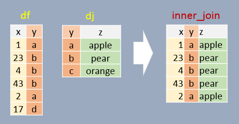

```r
full_join(df, dj, by = "y")
```

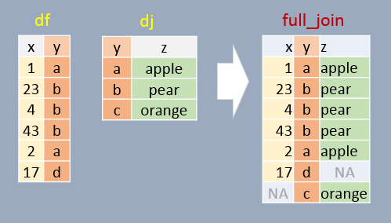

```r
left_join(df, dj, by = "y")
```

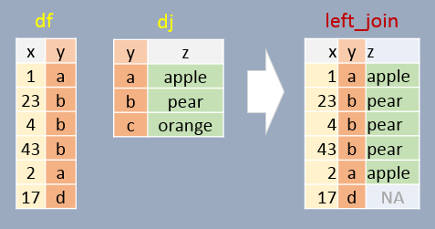

```r
right_join(df, dj, by = "y")
```

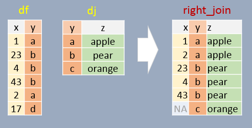

# 3 Grouping: aggregation

Last week we worked with the `dplyr` functions `group_by()` and `summarise()` to compute statistics based on column values for groups of observations (e.g. average life expectancy by continent-year).

`group_by()` in combination with `summarise()` is also how we aggregate observations and change the unit of analysis. For example, we might start with survey microdata (individual observations) and want to collapse individuals into meaningful groups such as families or states/provinces. This is the same functionality we introduced last week, but now we want to emphasize that we can use it to generate a new data frame for ongoing analysis (not just to obtain quick summary statistics by group).

As a reminder of how this works, let’s collapse all country observations in the original gapminder data frame to yearly observations with columns for global population and GDP… and with a bit of data manipulation to get there.

```r
#collapse to yearly (global) observations
gap_global <- gapminder %>%
  group_by(year) %>%
  mutate(gdp_tot = gdpPercap * pop) %>%  #get total GDP by country
  summarise(population = sum(pop), gdp = sum(gdp_tot)) %>%  #compute global pop and GDP
  mutate(gdppercap = gdp / population )  #compute global GDP per capita

#show resulting data frame
gap_global
```

```
## # A tibble: 12 x 4
##     year population     gdp gdppercap
##    <int>      <dbl>   <dbl>     <dbl>
##  1  1952 2406957150 7.04e12     2924.
##  2  1957 2664404580 8.90e12     3339.
##  3  1962 2899782974 1.10e13     3795.
##  4  1967 3217478384 1.42e13     4428.
##  5  1972 3576977158 1.84e13     5150.
##  6  1977 3930045807 2.23e13     5679.
##  7  1982 4289436840 2.54e13     5917.
##  8  1987 4691477418 3.01e13     6423.
##  9  1992 5110710260 3.45e13     6751.
## 10  1997 5515204472 4.10e13     7435.
## 11  2002 5886977579 4.73e13     8029.
## 12  2007 6251013179 5.81e13     9296.
```

# 4 Grouping: normalizing observations

Another application of `group_by()` is that it allows us to normalize variables based on group-wise statistics. Normalization can help us standardize the units of a variable for more meaningful measurement and comparisons over time/between groups. For example, comparing raw test scores between students in different years is misleading if the difficulty of the test varies over time. Instead we probably want to use *standardized* test scores, measured as z-scores instead of raw test scores.

```r
#collapse to yearly (global) observations w/standardized lifeExp
gap_z <- gapminder %>%
  group_by(year) %>%
  mutate(mean_life = mean(lifeExp), #compute mean lifeExp in each year across countries (store as col)
         sd_life = sd(lifeExp),      #compute s.d. lifeExp in each year across countries (store as col)
         life_z = (lifeExp - mean_life) / sd_life) %>% #normalize every lifeExp obs to a z-score (within-year)
  arrange(desc(life_z))

#look at most extreme country-year life expectancy observations after standardization
#(i.e. relative to mean among all countries in a given year)
gap_z %>% head(n = 5)
```

```
## # A tibble: 5 x 9
##   country     continent  year lifeExp     pop gdpPercap mean_life sd_life life_z
##   <fct>       <fct>     <int>   <dbl>   <int>     <dbl>     <dbl>   <dbl>  <dbl>
## 1 Norway      Europe     1952    72.7  3.33e6    10095.      49.1    12.2   1.93
## 2 Iceland     Europe     1952    72.5  1.48e5     7268.      49.1    12.2   1.92
## 3 Netherlands Europe     1952    72.1  1.04e7     8942.      49.1    12.2   1.89
## 4 Sweden      Europe     1952    71.9  7.12e6     8528.      49.1    12.2   1.87
## 5 Iceland     Europe     1957    73.5  1.65e5     9244.      51.5    12.2   1.80
```

```r
gap_z %>% tail(n = 5)
```

```
## # A tibble: 5 x 9
##   country      continent  year lifeExp    pop gdpPercap mean_life sd_life life_z
##   <fct>        <fct>     <int>   <dbl>  <int>     <dbl>     <dbl>   <dbl>  <dbl>
## 1 Swaziland    Africa     2007    39.6 1.13e6     4513.      67.0    12.1  -2.27
## 2 Sierra Leone Africa     1992    38.3 4.26e6     1069.      64.2    11.2  -2.30
## 3 Rwanda       Africa     1997    36.1 7.21e6      590.      65.0    11.6  -2.50
## 4 Cambodia     Asia       1977    31.2 6.98e6      525.      59.6    11.2  -2.53
## 5 Rwanda       Africa     1992    23.6 7.29e6      737.      64.2    11.2  -3.61
```

If you’re interested in learning more about normalization, [here](https://kharshit.github.io/blog/2018/03/23/scaling-vs-normalization) is a short primer on standardization vs. scaling as normalization approaches using R.

# 5 The apply family of functions

Recall that the base R `summary()` function is a quick and easy way to get a snapshot of the distribution of numeric variables. We’ve also used the `summarise()` function in the `dplyr` package to compute summary statistics. Another approach is to use an **apply** function to efficiently call another function multiple times for multiple objects or elements of objects (e.g. get the mean for different columns of data). Apply functions include `lapply()`, `sapply()`, `vapply()`, and `tapply()`. Let’s briefly introduce `sapply()` and `tapply()` in case they come in handy down the road.

`sapply()` will apply a specified function to each element of a list or vector and returns a corresponding list or vector of results.

```r
sapply(X, FUN)
Arguments:
-X: A vector or an object
-FUN: Function applied to each element of x
```

For example:

```r
#isolate all numeric gapminder columns for 2007 in new data frame
gap_cols <- gapminder %>% filter(year == 2007) %>% select(pop, lifeExp, gdpPercap)

#use sapply to apply mean function to all columns in gap_cols
sapply(gap_cols, mean)
```

```
##          pop      lifeExp    gdpPercap
## 4.402122e+07 6.700742e+01 1.168007e+04
```

`tapply()` is useful for factors, applying a specified function *to each level* of a given factor (e.g., to get group-specific means).

```r
tapply(X, INDEX, FUN = NULL)
Arguments:
-X: An object, usually a vector (stats will be computed based on X values)
-INDEX: A list containing factor (stats will be computed for each INDEX group)
-FUN: Function applied to each element of x (FUN specifies the type of statistic)
```

For example:

```r
#use tapply to get min lifeExp by country (i.e. for every level of country factor)
tapply(gapminder$lifeExp, gapminder$country, min) %>% head()
```

```
## Afghanistan     Albania     Algeria      Angola   Argentina   Australia
##      28.801      55.230      43.077      30.015      62.485      69.120
```

# 6 Dealing with missing values

It’s usually a good idea to assign all missing values–and values that we want R to treat as missing–as soon as you load your data. Recall one tool for doing this is to specify which characters should be treated as `NA` when reading in your data. Different functions for loading data have different options to specify which values to treat as `NA`; here is one example we used last week:

```r
#set na = option to specify strings to treat as NA
arrests_bds <- read_csv("microdata_BDS_inclass.csv", na = "")
```

Sometimes missing values will be assigned with specific codes in survey data (e.g. 999999). You can specify which values should be treated as `NA` when loading your data, or replace them after the fact.

In any event, getting a handle on which values should be treated as missing and why that is should be on the top of your to do list. In some instances you may want to keep all observations and exclude `NA`’s as needed when making certain calculations. In other instances, you may want to drop incomplete rows from your analysis so you have one complete **analysis sample** for all of your analysis.

Let’s introduce some tools for making decisions about `NA` values using the `healthexp` data from the World Bank. First let’s look at all observations with `NA` health expenditure data for 2002:

```r
#use is.na function filter to identify observations with NA health exp
healthexp %>% filter(year == 2002, is.na(healthexp) == TRUE)
```

```
## # A tibble: 35 x 4
##    country        Indicator.Name                                  year healthexp
##    <chr>          <chr>                                          <dbl>     <dbl>
##  1 Aruba          Current health expenditure per capita (curren…  2002        NA
##  2 Albania        Current health expenditure per capita (curren…  2002        NA
##  3 American Samoa Current health expenditure per capita (curren…  2002        NA
##  4 Bermuda        Current health expenditure per capita (curren…  2002        NA
##  5 Channel Islan… Current health expenditure per capita (curren…  2002        NA
##  6 Curacao        Current health expenditure per capita (curren…  2002        NA
##  7 Cayman Islands Current health expenditure per capita (curren…  2002        NA
##  8 Faroe Islands  Current health expenditure per capita (curren…  2002        NA
##  9 Gibraltar      Current health expenditure per capita (curren…  2002        NA
## 10 Greece         Current health expenditure per capita (curren…  2002        NA
## # … with 25 more rows
```

Right away we can recognize that many missing observations–though not all–are for sub-national territories that may not report this information (e.g. Aruba is considered a “constituent country of the Kingdom of the Netherlands”).

Here is an easy way to remove all observations with `healthexp` equal to `NA`, if that is what we decide to do:

```r
#use na.omit function to drop all observations with NA health exp
healthexp_2002 <- healthexp %>% filter(year == 2002)
na.omit(healthexp_2002)
```

```
## # A tibble: 229 x 4
##    country            Indicator.Name                              year healthexp
##    <chr>              <chr>                                      <dbl>     <dbl>
##  1 Afghanistan        Current health expenditure per capita (cu…  2002      16.2
##  2 Angola             Current health expenditure per capita (cu…  2002      29.0
##  3 Andorra            Current health expenditure per capita (cu…  2002    2256.
##  4 Arab World         Current health expenditure per capita (cu…  2002     117.
##  5 United Arab Emira… Current health expenditure per capita (cu…  2002     851.
##  6 Argentina          Current health expenditure per capita (cu…  2002     223.
##  7 Armenia            Current health expenditure per capita (cu…  2002      59.6
##  8 Antigua and Barbu… Current health expenditure per capita (cu…  2002     512.
##  9 Australia          Current health expenditure per capita (cu…  2002    1764.
## 10 Austria            Current health expenditure per capita (cu…  2002    2486.
## # … with 219 more rows
```

Note that `NA` observations like Aruba are dropped from the data frame returned by `na.omit()`.